# Titanic dataset analysis:

I have choosed the titanic data set for analysis , Following are the question i would like to answer in provided dataset.

1. Is there any relation between the sex of the passenger who is travelling and the chances of his or her survival(does any sympathy shown towards the particular sex).
2. Does we have any relationship between the age of the person and chances of his/her survival(does any sympathy shows toward the childern and older people)
3. Is there any relation between the class of passenger travelling and chances of his or her survival(does any preference given on the basis of class)

Loading the Titanic dataset CSV file.

Data Acquisition:

```python
import pandas as pd
titanicDataset=pd.read_csv("titanic-data.csv")
titanicDataset.head()
```

|  | PassengerId | Survived | Pclass | Name | Sex | Age | SibSp | Parch | Ticket | Fare | Cabin | Embarked |
| --- | --- | --- | --- | --- | --- | --- | --- | --- | --- | --- | --- | --- |
| 0 | 1 | 0 | 3 | Braund, Mr. Owen Harris | male | 22.0 | 1 | 0 | A/5 21171 | 7.2500 | NaN | S |
| 1 | 2 | 1 | 1 | Cumings, Mrs. John Bradley (Florence Briggs Th... | female | 38.0 | 1 | 0 | PC 17599 | 71.2833 | C85 | C |
| 2 | 3 | 1 | 3 | Heikkinen, Miss. Laina | female | 26.0 | 0 | 0 | STON/O2. 3101282 | 7.9250 | NaN | S |
| 3 | 4 | 1 | 1 | Futrelle, Mrs. Jacques Heath (Lily May Peel) | female | 35.0 | 1 | 0 | 113803 | 53.1000 | C123 | S |
| 4 | 5 | 0 | 3 | Allen, Mr. William Henry | male | 35.0 | 0 | 0 | 373450 | 8.0500 | NaN | S |

There is some missing data in titanicDataset in following fields:

1. Age
2. Cabin
3. Embarked

```python
titanicDataset.info()
```

```
<class 'pandas.core.frame.DataFrame'>
RangeIndex: 891 entries, 0 to 890
Data columns (total 12 columns):
PassengerId    891 non-null int64
Survived       891 non-null int64
Pclass         891 non-null int64
Name           891 non-null object
Sex            891 non-null object
Age            714 non-null float64
SibSp          891 non-null int64
Parch          891 non-null int64
Ticket         891 non-null object
Fare           891 non-null float64
Cabin          204 non-null object
Embarked       889 non-null object
dtypes: float64(2), int64(5), object(5)
memory usage: 83.6+ KB
```

Let us find out the fields where data is missing.

```python
titanicDataset.isnull().sum()
```

```
PassengerId      0
Survived         0
Pclass           0
Name             0
Sex              0
Age            177
SibSp            0
Parch            0
Ticket           0
Fare             0
Cabin          687
Embarked         2
dtype: int64
```

As we have find out there are following three fields where some data is void.

1. Age
2. Cabin
3. Embarked

Lets start data wrangling one by one.

First of all we are going to clean the null values for age. here we are going to update mean value(as per Sex and class) for age to the missing values.

```python
titanicDataset.isnull().sum()
titanicDataset['Age']=titanicDataset.groupby(['Sex','Pclass']).transform(lambda x: x.fillna(x.mean()))['Age']
titanicDataset.isnull().sum()
```

[output not shown]

After cleaning age field data ,now we are going to treat null values for the cabin, here we are going to put some random number for cabin instead of null values.

```python
import numpy as np
titanicDataset['Cabin'].fillna(np.random.randint(999999,9999999,size=1)[0],inplace=True)
titanicDataset.isnull().sum()
```

[output not shown]

```python
titanicDataset['Embarked'].bfill(inplace=True)
titanicDataset.isnull().sum()
```

```
PassengerId    0
Survived       0
Pclass         0
Name           0
Sex            0
Age            0
SibSp          0
Parch          0
Ticket         0
Fare           0
Cabin          0
Embarked       0
dtype: int64
```

## Imports and function that are used in our analysis

For anlysis and visualizing the question we have state ,we have used the following following package and the custom function(we have created).

```python
import matplotlib.pyplot as plt
import matplotlib.pylab as py
import seaborn as sns
%matplotlib inline
```

```python
#function for the histogram plot for seniors and childerns
def survivalplot(dataset,childOrOld):
    dataset['Survived']=dataset['Survived'].replace({0:'No',1:'Yes'},inplace=False)
    if childOrOld=='old':
        partDataset=newTitanicDataset[dataset['Age']>60]
        chart=partDataset.groupby('Survived')['Age'].plot(kind='hist',bins=range(60,85,2),alpha=0.6,title='Old people survival' ,normed=True)
    else:
        partDataset=newTitanicDataset[dataset['Age']<16]
        chart=partDataset.groupby('Survived')['Age'].plot(kind='hist',bins=range(0,16,2),alpha=0.6,title='child survival' ,normed=True)
    py.xlabel('Age')
    py.ylabel('Proportion of people survived')
    plt.legend(title='Survived')
    plt.show()
```

```python
def barplot(dataval,variable,binvalues,binlabel,xlabel,ylabel,titleval,ydes,hueval):
    dataval.loc[:,xlabel] = pd.cut(dataval[variable], bins=binvalues, labels=binlabel)
    if hueval==False:
        ax=sns.barplot(x=xlabel, y=ylabel, data=dataval,ci=None)
        ax.set(ylabel=ydes,title=titleval)
        tickval=ax.get_yticks()
        ax.set_yticklabels(['{:3.2f}%'.format(x*100) for x in tickval])
    else:
        ax=sns.barplot(x=xlabel, y=ylabel,hue=hueval, data=dataval,ci=None)
        ax.set(ylabel=ydes,title=titleval)
        tickval=ax.get_yticks()
        ax.set_yticklabels(['{:3.2f}%'.format(x*100) for x in tickval])
    plt.show()
```

```python
def get_percentage(num,demon):
    return (float(num)/demon)*100
```

```python
#function to create barplot from male/female survival out of total travellers.
def barplot_for_per(Dataset,fromsex,tosex):
    short=Dataset[Dataset['Sex']==tosex]
    short[short['Survived']==1]
    Dataset['Survived']=short['Survived']
    Dataset['Survived'].fillna(0,inplace=True)
    Dataset['Sex']=Dataset['Sex'].replace(fromsex,tosex)
    ax=sns.barplot(x="Sex", y="Survived", data=Dataset)
    ax.set(ylabel='Pecentage of survival',title='Survival of a particular sex')
    tickval=ax.get_yticks()
    ax.set_yticklabels(['{:3.2f}%'.format(x*100) for x in tickval])
    plt.show()
```

```python
#creating function to create the point plot
def pointplot(dataset,x_val,y_val,y_label,title_val):
    ax=sns.pointplot(x=x_val, y=y_val, data=dataset);
    ax.set(ylabel=y_label,title=title_val)
    tickval=ax.get_yticks()
    ax.set_yticklabels(['{:3.2f}%'.format(x*100) for x in tickval])
    plt.grid()
    plt.show()
```

# Question 1:

Is there any relation between the sex of the passenger who is travelling and the chances of his or her survival(does any sympathy shown towards the particular sex).

First of all lets find out the number of males and females present in dataset.

```python
totalpassenger=titanicDataset['Sex'].value_counts()
totalpassenger
```

```
male      577
female    314
Name: Sex, dtype: int64
```

Segregating the survived passenger data from the given dataset

```python
titanicDatasetQ1=titanicDataset[['Survived']]
```

```python
import matplotlib.pyplot as plt
import seaborn as sns
%matplotlib inline
survivalList=titanicDatasetQ1['Survived']==1
survivalPeople=titanicDataset[survivalList]
```

Now survival dataset is ready , we go ahead and find out how many males or females were survived.

```python
groupedBySex=survivalPeople['Sex'].value_counts()
groupedBySex
```

```
female    233
male      109
Name: Sex, dtype: int64
```

Percentage of male and female survived out of total number of male and female travelling in the ship respectively

```python
#get_percentage(groupedBySex['female'],totalpassenger['female'])
titanicDataset.groupby('Sex')['Survived'].mean()*100
```

```
Sex
female    74.203822
male      18.890815
Name: Survived, dtype: float64
```

Now let visualize how survival prefrences were varied on the basis of the sex of passenger

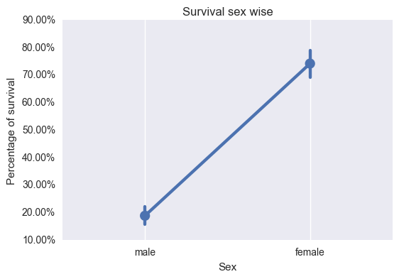

```python
pointplot(titanicDataset,'Sex','Survived','Percentage of survival','Survival sex wise')
```

Above point plot clearly indicates that prefrence were given to females during the survival operation.

lets visualize the survival of a passenger on the basic of sex again,This time with the bar plot.

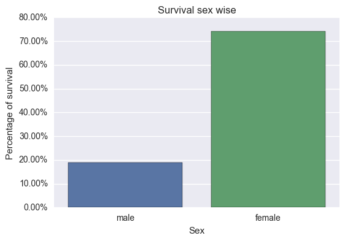

```python
sexTitanicDatset=titanicDataset.copy()
sexTitanicDatset['Sex']=titanicDataset['Sex'].replace(['male','female'],[1,2])
binvalues=[0,1,2]
binlabel=['male','female']
xlabel='Sex'
ylabel='Survived'
ydesc='Percentage of survival'
title='Survival sex wise'
barplot(sexTitanicDatset,'Sex',binvalues,binlabel,xlabel,ylabel,title,ydesc,False)
```

Difference in survival prefrences is quite evident in above bar plot also.

Now lets more deep dive our analysis from catagorical survival to the survival of particular sex from the total number of passenger travelling.

Percentage of female survived out of total number of traveller in the ship.

```python
get_percentage(groupedBySex['female'],totalpassenger.sum())
```

```
26.15039281705948
```

Percentage of male survived out of total number of traveller in the ship.

```python
get_percentage(groupedBySex['male'],totalpassenger.sum())
```

```
12.233445566778901
```

lets visualize the number of male survived out of total travellers.

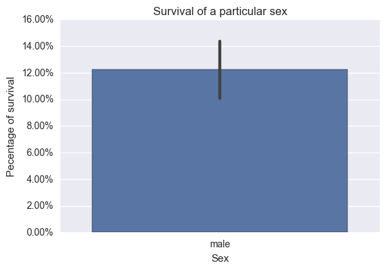

```python
twikTitanicDataset=titanicDataset.copy()
barplot_for_per(twikTitanicDataset,'female','male')
```

Above bar chart clearly shows that approximately 12% of males were survived out of total number of passenger travelling.

Now visualize percentage of female survived out of total number of travellers.

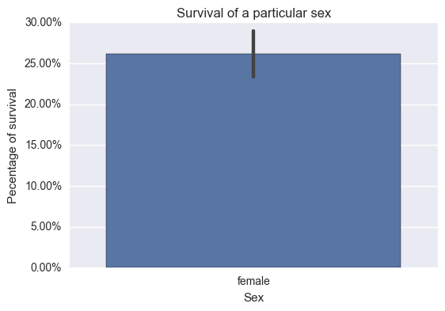

```python
twikTitanicDataset=titanicDataset.copy()
barplot_for_per(twikTitanicDataset,'male','female')
```

Above bar chart shows that approximately 26% of female were survived out of total number of passenger travelling.

###### Chart after chart cleary indicates that "there is more prefrences were given to a females while survival operation than male".Same thing is also conveyed by the following stats

1. 74%(approx) females were survived from the total number of females travelling in the ship, whereas only 19%(approx) male were survived out of total number of male travelling in the ship.
2. 26%(approx) females were survived from total number of passenger travelling ship(both male and female).whereas only 12%(approx) of male were survived from total number of passenger travelling ship.

# Question 2:

Does we have any relationship between the age of the person and chances of his/her survival(does any sympathy shows toward the childern and older people)

lets start this analysis by finding the average age of people travelling in ship.

```python
titanicDataset['Age'].mean()
```

```
29.318642716644145
```

Now lets find the average age of survived people.

```python
survivalPeople['Age'].mean()
```

```
28.183708986925815
```

Now lets visualize number of people were survived age wise through histogram.

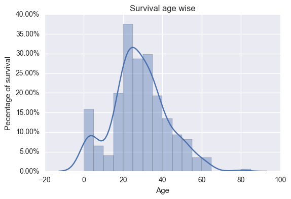

```python
#survivalAge=survivalPeople['Age'].plot(kind='hist',bins=range(0,90,5),title='Survival age wise')
#survivalAge.set(xlabel='Age')

ax=sns.distplot(survivalPeople['Age'],bins=range(0,90,5));
ax.set(ylabel='Pecentage of survival',title='Survival age wise')
tickval=ax.get_yticks()
ax.set_yticklabels(['{:3.2f}%'.format(x*1000) for x in tickval])

#ax.set()
```

this graph clearly shows that most of the people who survived were quite young between 20-40.

Now I want to check age of the people who were not able to survived.

```python
nonSurvivalList=titanicDatasetQ1['Survived']==0
nonSurvivalPeople=titanicDataset[nonSurvivalList]
```

Average age of the people who were not able to survive.

```python
nonSurvivalPeople['Age'].mean()
```

```
30.025650613845738
```

Average age of survived people and non survied people looks same approximately.For more clarity we can have a look on the histogram for both survived(shown with green color) and non survived (shown with red color)

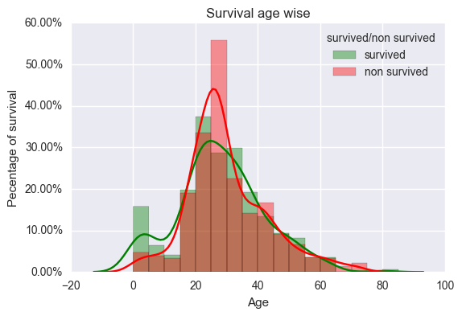

```python
#nonSurvivalPeople['Age'].plot(kind='hist',bins=range(0,90,5),colormap='Reds_r',title='Survival Age Wise',legend=True,label='Non Survived')
#survivalAge=survivalPeople['Age'].plot(kind='hist',bins=range(0,90,5),alpha=0.6,colormap='Greens_r',legend=True,label='Survived' )
#survivalAge.set(xlabel='Age')



ax=sns.distplot(survivalPeople['Age'],bins=range(0,90,5),label='survived',color='g');
sns.distplot(nonSurvivalPeople['Age'],bins=range(0,90,5),label='non survived',color='r');
ax.set(ylabel='Pecentage of survival',title='Survival age wise')
tickval=ax.get_yticks()
ax.set_yticklabels(['{:3.2f}%'.format(x*1000) for x in tickval])
plt.legend(title='survived/non survived')
```

Note: There red spike shown in the histogram is may be because of the artificial data we have filled for 177 entries, which are missing in age column

Hikes in histogram clearly shows that most of life survived and life lost were of the similar age group.we can not cleary say that ,if there some special prefrences given to some special age group.

But also there is small hike of green is present between 0 to 16 age,which can help to answer a part of question which says that is there any special prefrences were given to childern and senior people

lets start our analysis for whether any special prefrence were given to the old people

lets check how many old(age > 60) people were travelling in the ship

```python
totalOldPassenger=titanicDataset[titanicDataset['Age']>60]['PassengerId'].count()
totalOldPassenger
```

```
22
```

How many of those old passenger survived.

```python
survivedOldPassenger=survivalPeople[survivalPeople['Age']>60]['PassengerId'].count()
survivedOldPassenger
```

```
5
```

Number of old passenger who were not able to survive.

```python
nonSurvivedOldPassenger=nonSurvivalPeople[nonSurvivalPeople['Age']>60]['PassengerId'].count()
nonSurvivedOldPassenger
```

```
17
```

Lets check what percentage of the old passenger were survived during titanic accident.

```python
get_percentage(survivedOldPassenger,totalOldPassenger)
```

```
22.727272727272727
```

Now lets present the age group by survival proportion for the old people.

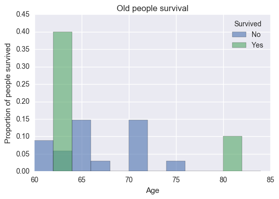

```python
oldDataset=titanicDataset.copy()
survivalplot(oldDataset,'old')
```

In above histogram we can view that a small hike at 62 to 65 where senior people able to survive, but most of histogram shows most of the seniors were not able to make it.

After analysing the old people survival and lets analysis the childern(age <16) ,how about there survival.

Total number of child passenger in the ship.

```python
totalChildPassenger=titanicDataset[titanicDataset['Age']<16]['PassengerId'].count()
totalChildPassenger
```

```
83
```

Number of child passenger who survived.

```python
survivedChildPassenger=survivalPeople[survivalPeople['Age']<16]['PassengerId'].count()
survivedChildPassenger
```

```
49
```

Number of child passenger who were not able to survive.

```python
nonSurvivedChildPassenger=nonSurvivalPeople[nonSurvivalPeople['Age']<16]['PassengerId'].count()
nonSurvivedChildPassenger
```

```
34
```

Percentage of child passenger survival

```python
get_percentage(survivedChildPassenger,totalChildPassenger)
```

```
59.036144578313255
```

Lets visualize child passenger survival on different age group through histogram

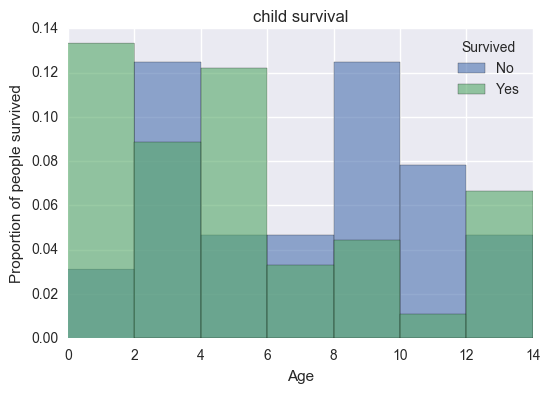

```python
childDataset=titanicDataset.copy()
survivalplot(childDataset,'child')
```

Following chart summarize the survival of people age group wise during titanic accident.

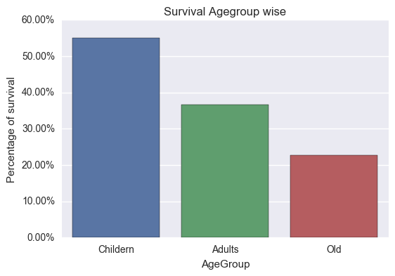

```python
binvalues=[0,16,60,90]
binlabel=['Childern','Adults','Old']
xlabel='AgeGroup'
ylabel='Survived'
title='Survival Agegroup wise'
ydesc='Percentage of survival'
barplot(titanicDataset,'Age',binvalues,binlabel,xlabel,ylabel,title,ydesc,False)
```

There are some special cases which we have analyzed (if some special prefrence were given to old people and childern while carrying out survival operation). following are my findings:

1. It is also very visible that no special sympathy shown towards the old people , as the chart show only 5 old people(age > 60) were saved out of 22 people.
2. There are evidence that some prefrence given to the children(age <16) while carrying out the survival operation

# Question 3:

Is there any relation between the class of passenger travelling and chances of his or her survival(does any preference given on the basis of class)

lets start our analysis with the number of people travelling in each class

```python
titanicDataset['Pclass'].value_counts()
```

```
3    491
1    216
2    184
Name: Pclass, dtype: int64
```

Now lets check the number of people who survived in each class.

```python
survivalPeople['Pclass'].value_counts()
```

```
1    136
3    119
2     87
Name: Pclass, dtype: int64
```

lets analyze survived people for a particular class through the point chart.

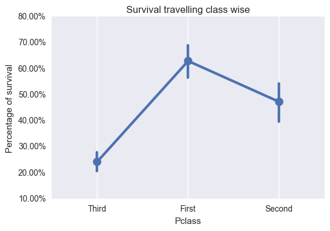

```python
newSurvivalPeople=titanicDataset.copy()
newSurvivalPeople['Pclass']=newSurvivalPeople['Pclass'].replace([1,3,2],['First','Third','Second'])
pointplot(newSurvivalPeople,'Pclass','Survived','Percentage of survival','Survival travelling class wise')
```

above chart clearly indicates that special prefrences were given to the first class traveller in the survival operations.

lets check the other side also.

Analysis on the people who were not able to survived class wise

```python
nonSurvivalPeople['Pclass'].value_counts()
```

```
3    372
2     97
1     80
Name: Pclass, dtype: int64
```

Lets plot the point chart for the people who were not able to survive travelling class wise

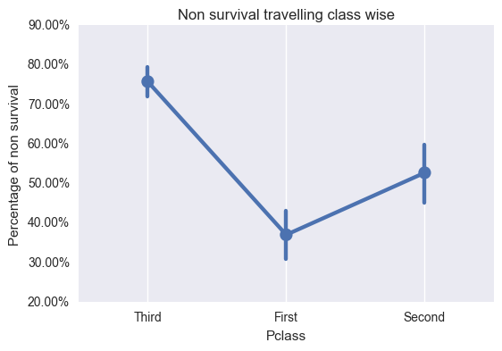

```python
newSurvivalPeople=titanicDataset.copy()
newSurvivalPeople['Pclass']=newSurvivalPeople['Pclass'].replace([1,3,2],['First','Third','Second'])
newSurvivalPeople['Survived']=newSurvivalPeople['Survived'].replace({0:1,1:0})
pointplot(newSurvivalPeople,'Pclass','Survived','Percentage of non survival','Non survival travelling class wise')
```

This chart is just opposite of what we have seen for the people survived class wise.Again this chart clearly indicates approx. 80% of the people who were travelling through the 3rd class have lost their life,whereas only 36%(approx) of people who travelling through 1st class were not able to make it.

lets once again see the percentage of people survival travelling class wise. this time through the bar chart.

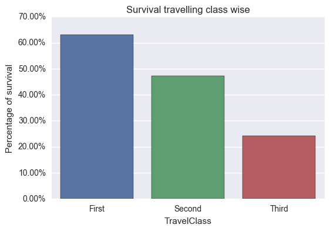

```python
binvalues=[0,1,2,3]
binlabel=['First','Second','Third']
xlabel='TravelClass'
ylabel='Survived'
title='Survival travelling class wise'
ydesc='Percentage of survival'
barplot(titanicDataset,'Pclass',binvalues,binlabel,xlabel,ylabel,title,ydesc,False)
```

###### For this question we have analysed on the both ends (survival and non survival).we have seen chart after chart and numberical figure after numberical figure .All are indicating following trends:

1. Most preference for life saving was given to the passenger who were travelling in 1st class,More than 60% were saved.
2. Least preference was given to the passenger who were travelling through 3rd class.Approx 80% have to loose their life.

# Miscellaneous Question:

##### Answering first 3 question raise an another question:

In analysis 1st and 3rd shows that there were some favour given while carrying out life saving activies.

1. 1st analysis shows that the favour was given on sex basis . More female were saved.
2. 3rd analysis shows that the favour was given for particular class. More first class traveller were saved.

Now i want to analysis is there any relation between the two analysis. following are the question which needs to be answered.

1. How many females were saved who were travelling through first class.
2. How many females were saved who were travelling in other than first class.

Lets check what percentage of female were survived on the basis of their travelling class.

```python
fSurvivalPeople=titanicDataset.copy()
fSurvivalPeople=fSurvivalPeople[fSurvivalPeople['Sex']=='female']
```

Following is chart which shows the percentage of female survived on the basis of class.

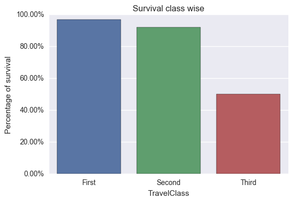

```python
binvalues=[0,1,2,3]
binlabel=['First','Second','Third']
xlabel='TravelClass'
ylabel='Survived'
title='Survival class wise'
ydesc='Percentage of survival'
barplot(fSurvivalPeople,'Pclass',binvalues,binlabel,xlabel,ylabel,title,ydesc,False)
```

Above bar clearly states that more than 90% of female were survived who were travelling in first class, whereas only 50% of the female were saved who were travelling in third class.

Following chart summarize the number of male/female survived travelling class wise.

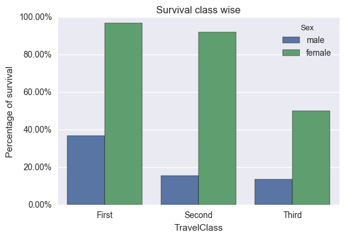

```python
binvalues=[0,1,2,3]
binlabel=['First','Second','Third']
xlabel='TravelClass'
ylabel='Survived'
title='Survival class wise'
ydesc='Percentage of survival'
barplot(titanicDataset,'Pclass',binvalues,binlabel,xlabel,ylabel,title,ydesc,'Sex')
```

Above chart cleary states that preference were given to the first class traveller(male and female) while carrying out the survival operation and in first class travellers also more sympathy was shown towards the females.

Lets try to prove the samething again but this time which different visualization.

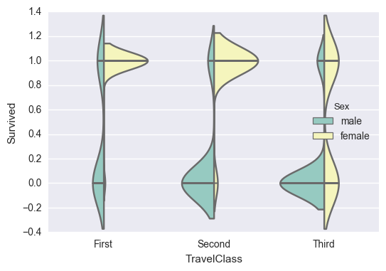

```python
sns.violinplot(x="TravelClass", y="Survived", hue="Sex", data=titanicDataset,
               split=True, inner="stick", palette="Set3");
```

In aboe violin plot also , we can clearly figure out the color assign to female is more flatten out in first of travelclass than the third travelclass

###### Both charts clearly states the following.

1. Special preference was given to the females who were travelling through 1st class
2. least preference was given to the females who were travelling in third class.

# Conclusion:

### Lets conclude our analysis by answering all the question that we have put at the start.

Question 1:

Is there any relation between the sex of the passenger who is travelling and the chances of his or her survival(does any sympathy shown towards the particular sex).

Answer 1:

From the analysis that has been performed on question 1. it is very evident that survival preference were given to the female as compared to the males (74% female were saved whereas only 18% of male were saved)

Question 2:

Does we have any relationship between the age of the person and chances of his/her survival(does any sympathy shows toward the childern and older people)

Answer 2:

[output not shown]

Question 3:

Is there any relation between the class of passenger travelling and chances of his or her survival(does any preference given on the basis of class)

After answering all the question now we want to discuss two other important question:

1. Does our analysis having any limitation or shortcoming.
2. Does the trends that we have seen in our analysis are significant.

Question :

Does our analysis having any limitation or shortcoming.

Answer :

we have also put the artifical data for cabin(using random number) and embarkation(using bfill function) in our dataset. But that would not effect our analysis as we have not used these fields for our analysis.

Question:

Does the trends that we have seen in our analysis are significant?

Answer:

After answering all the questions we can have find out there some clear indications which suggest the correlation betwen the different varibales(like travelclass and chances of survival, preference give to particular sex while survival)

We can further check out whether these correlation are significant or not using statistics. Since we are provided with the sample dataset of traveller of titanic we can carry out the T-Test statistics , to check whether this co-relation has any significance or not.

###### If we want conclude the complete story in 2 lines then we can say as follows:

Most the female who belong to 1st class were survived during the titanic accident ,with some sampathy shown towards the childern and no sympathy shown towards old people during survival operations.

##### Further research that can be carried out:

To drill more of this data we can also do some analysis on the basis of a cabin a passenger is travelling and his chances of survival. May be the passenger who are travelling in the cabins which are on the upper site of the ship had more chance of survival.